# Using Baseball Data to Predict the Batting Score Type that Generates the Most Wins

## The Lahman Dataset

The dataset has a multitude of features and is highly recommended for review by anyone that is a baseball or sports enthusiast.

**Install Dataset and Libraries**

```r
if(!require(Lahman))install.packages("Lahman", repos = "http://cran.us.r-project.org")
library(tidyverse)
library(Lahman)
library(dslabs)
ds_theme_set()
# Teams
#  Review dataset if required
# summary(Lahman)
# write.csv(Lahman, "data/Lahman.csv")
```

This analysis will use the “Teams” data, and will analyze the following variables:

- **Bases on balls (BB):** a pitcher does not throw the ball into the strike zone, and the batter walks to first base.
- **Single:** the batter hits the ball and makes it to first base.
- **Double:** the batter hits the ball and makes it to second base.
- **Triple:** the batter hits the ball and makes it to third base.
- **Homeruns (HRs):** a player hits the ball outside of the baseball park boundary and scores, as well as any other players on bases score.

A full list of the variables can be reviewed from the summary statistics:

```
##      yearID     lgID          teamID        franchID       divID
##  Min.   :1871   AA:  85   CHN    : 146   ATL    : 146   Length:2985
##  1st Qu.:1922   AL:1295   PHI    : 139   CHC    : 146   Class :character
##  Median :1967   FL:  16   PIT    : 135   CIN    : 140   Mode  :character
##  Mean   :1959   NA:  50   CIN    : 132   PIT    : 140
##  3rd Qu.:1997   NL:1519   SLN    : 130   STL    : 140
##  Max.   :2021   PL:   8   BOS    : 121   PHI    : 139
##                 UA:  12   (Other):2182   (Other):2134
##       Rank             G           Ghome           W               L
##  Min.   : 1.00   Min.   :  6   Min.   :24    Min.   :  0.0   Min.   :  4.0
##  1st Qu.: 2.00   1st Qu.:154   1st Qu.:77    1st Qu.: 66.0   1st Qu.: 65.0
##  Median : 4.00   Median :159   Median :81    Median : 77.0   Median : 76.0
##  Mean   : 4.04   Mean   :150   Mean   :78    Mean   : 74.6   Mean   : 74.6
##  3rd Qu.: 6.00   3rd Qu.:162   3rd Qu.:81    3rd Qu.: 87.0   3rd Qu.: 87.0
##  Max.   :13.00   Max.   :165   Max.   :84    Max.   :116.0   Max.   :134.0
##                                NA's   :399
##     DivWin             WCWin              LgWin              WSWin
##  Length:2985        Length:2985        Length:2985        Length:2985
##  Class :character   Class :character   Class :character   Class :character
##  Mode  :character   Mode  :character   Mode  :character   Mode  :character
##
##
##
##
##        R              AB             H             X2B           X3B
##  Min.   :  24   Min.   : 211   Min.   :  33   Min.   :  1   Min.   :  0.0
##  1st Qu.: 614   1st Qu.:5135   1st Qu.:1299   1st Qu.:194   1st Qu.: 29.0
##  Median : 691   Median :5402   Median :1390   Median :234   Median : 40.0
##  Mean   : 681   Mean   :5129   Mean   :1339   Mean   :229   Mean   : 45.7
##  3rd Qu.: 764   3rd Qu.:5519   3rd Qu.:1465   3rd Qu.:272   3rd Qu.: 59.0
##  Max.   :1220   Max.   :5781   Max.   :1783   Max.   :376   Max.   :150.0
##
##        HR            BB            SO             SB            CS
##  Min.   :  0   Min.   :  1   Min.   :   3   Min.   :  1   Min.   :  3
##  1st Qu.: 45   1st Qu.:426   1st Qu.: 516   1st Qu.: 62   1st Qu.: 33
##  Median :110   Median :494   Median : 761   Median : 93   Median : 44
##  Mean   :106   Mean   :474   Mean   : 762   Mean   :109   Mean   : 47
##  3rd Qu.:155   3rd Qu.:554   3rd Qu.: 990   3rd Qu.:137   3rd Qu.: 56
##  Max.   :307   Max.   :835   Max.   :1596   Max.   :581   Max.   :191
##                NA's   :1     NA's   :16     NA's   :126   NA's   :832
```

[output cut: 33 more lines]

```
##  Min.   : 60   Min.   : 60   Length:2985        Length:2985
##  1st Qu.: 97   1st Qu.: 97   Class :character   Class :character
##  Median :100   Median :100   Mode  :character   Mode  :character
##  Mean   :100   Mean   :100
##  3rd Qu.:103   3rd Qu.:103
##  Max.   :129   Max.   :141
##
##  teamIDretro
##  Length:2985
##  Class :character
##  Mode  :character
##
##
##
##
```

The initial process step includes exploring some of the data, these scatterplots show the relationship of homeruns, bases on balls, and singles that have lead to winning games.

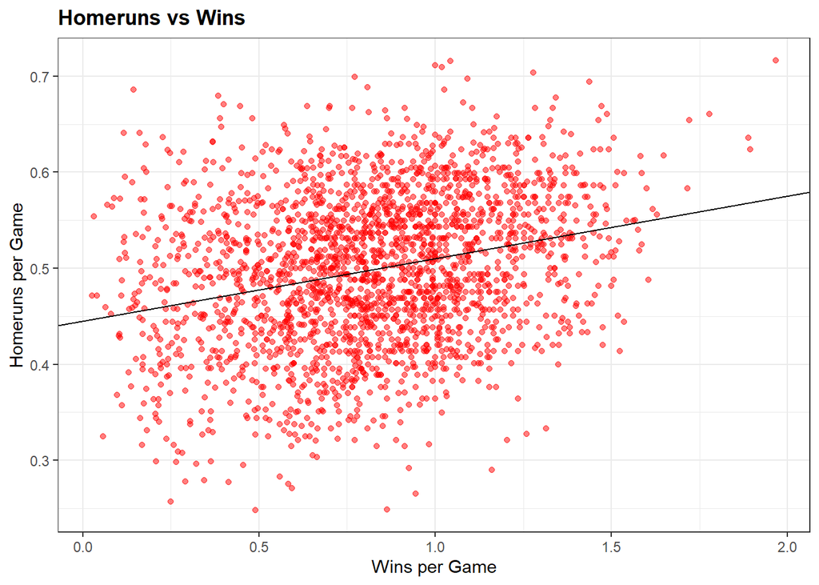

```r
homeruns <- Teams %>%
  filter(yearID %in% 1917:2021) %>%
  mutate(HR_per_game = HR / G) %>%
  select(HR_per_game)

wins <- Teams %>%
  filter(yearID %in% 1917:2021) %>%
  mutate(wins_per_game = W / G) %>%
  select(wins_per_game)

mu_x <- sapply(homeruns, mean)
mu_y <- sapply(wins, mean)
s_x <- sapply(homeruns, sd)
s_y <- sapply(wins, sd)
r <- cor(homeruns, wins)
m <- r * s_y/s_x
b <- mu_y - m*mu_x

# Scatterplot of the relationship between HRs and wins
hrwin <- Teams %>% filter(yearID %in% 1917:2021) %>%
  mutate(HR_per_game = HR / G, wins_per_game = W / G) %>%
  ggplot(aes(HR_per_game, wins_per_game)) +
  ggtitle("Homeruns vs Wins") +
  geom_point(alpha = 0.5, color = "red") +
  geom_abline(intercept = b, slope = m, color = "black") +
  labs(x="Wins per Game",y="Homeruns per Game")
hrwin
```

Scatterplot with regression line showing the relationship between bases on balls and wins:

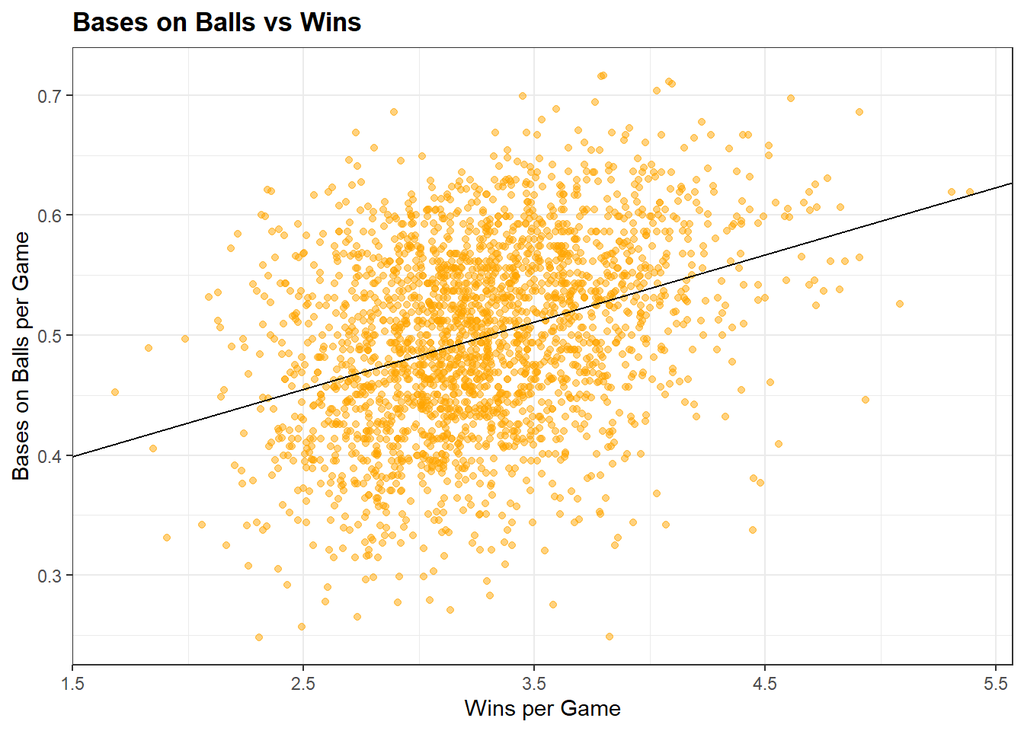

```r
bases_on_balls <- Teams %>%
  filter(yearID %in% 1917:2021) %>%
  mutate(BB_per_game = BB / G) %>%
  select(BB_per_game)

mu_x_BB <- sapply(bases_on_balls, mean)
mu_y <- sapply(wins, mean)
s_x_BB <- sapply(bases_on_balls, sd)
s_y <- sapply(wins, sd)
r <- cor(bases_on_balls, wins)
m <- r * s_y/s_x_BB
b <- mu_y - m*mu_x_BB

# Scatterplot of the relationship between BBs and wins
bbwin <- Teams %>% filter(yearID %in% 1917:2021) %>%
  mutate(BB_per_game = BB / G, wins_per_game = W / G) %>%
  ggplot(aes(BB_per_game, wins_per_game)) +
  ggtitle("Bases on Balls vs Wins") +
  geom_point(alpha = 0.5, color = "orange") +
  geom_abline(intercept = b, slope = m, color = "black") +
  labs(x="Wins per Game",y="Bases on Balls per Game")
bbwin
```

Scatterplot with regression line showing the relationship between singles and wins:

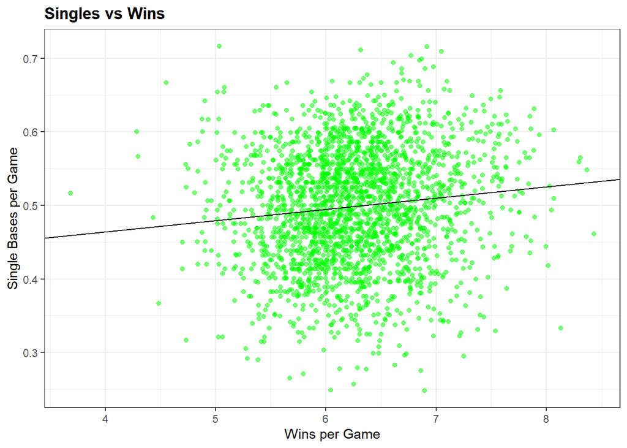

```r
# Regression line computations for singles and wins
singles <- Teams %>%
  filter(yearID %in% 1917:2021) %>%
  mutate(singles_per_game = (H-HR-X2B-X3B) / G) %>%
  select(singles_per_game)

mu_x_S <- sapply(singles, mean)
mu_y <- sapply(wins, mean)
s_x_S <- sapply(singles, sd)
s_y <- sapply(wins, sd)
r <- cor(singles, wins)
m <- r * s_y/s_x_S
b <- mu_y - m * mu_x_S

# Scatterplot of the relationship between SBs and wins
swins <- Teams %>% filter(yearID %in% 1917:2021) %>%
  mutate(singles_per_game = (H-HR-X2B-X3B) / G, wins_per_game = W / G) %>%
  ggplot(aes(singles_per_game, wins_per_game)) +
  ggtitle("Singles vs Wins") +
  geom_point(alpha = 0.5, color = "green") +
  geom_abline(intercept = b, slope = m, color = "black") +
  labs(x="Wins per Game",y="Single Bases per Game")
swins
```

Scatterplot with regression line showing the relationship between doubles and wins:

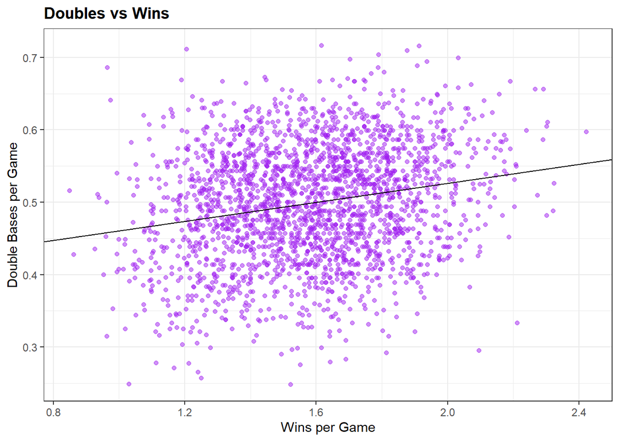

```r
# Regression line computations for doubles and wins
doubles <- Teams %>%
  filter(yearID %in% 1917:2021) %>%
  mutate(doubles_per_game = X2B / G) %>%
  select(doubles_per_game)

mu_x_D <- sapply(doubles, mean)
mu_y <- sapply(wins, mean)
s_x_D <- sapply(doubles, sd)
s_y <- sapply(wins, sd)
r <- cor(doubles, wins)
m <- r * s_y/s_x_D
b <- mu_y - m * mu_x_D

# Scatterplot of the relationship between double bases and wins
dwins <- Teams %>% filter(yearID %in% 1917:2021) %>%
  mutate(doubles_per_game = X2B / G, wins_per_game = W / G) %>%
  ggplot(aes(doubles_per_game, wins_per_game)) +
  ggtitle("Doubles vs Wins") +
  geom_point(alpha = 0.5, colour = "purple") +
  geom_abline(intercept = b, slope = m, color = "black") +
  labs(x="Wins per Game",y="Double Bases per Game")
dwins
```

Scatterplot with regression line showing the relationship between triples and wins:

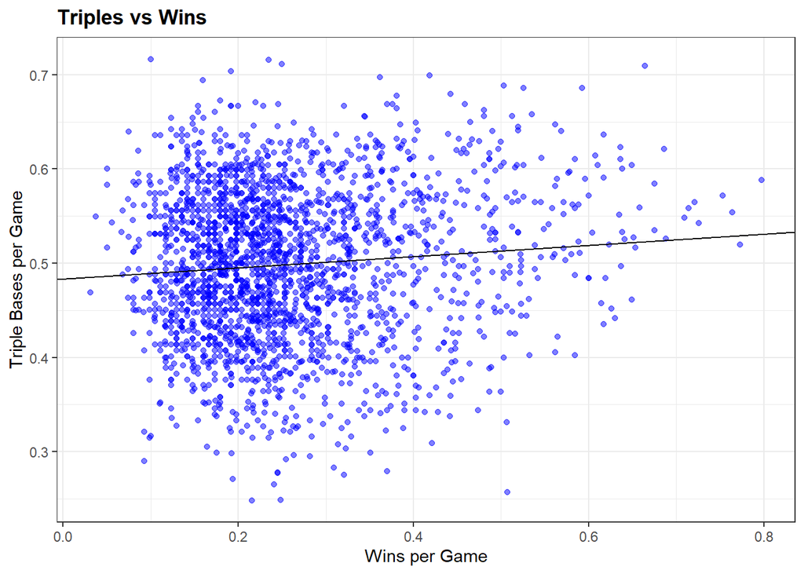

```r
# Regression line computations for triples and wins
triples <- Teams %>%
  filter(yearID %in% 1917:2021) %>%
  mutate(triples_per_game = X3B / G) %>%
  select(triples_per_game)

mu_x_T <- sapply(triples, mean)
mu_y <- sapply(wins, mean)
s_x_T <- sapply(triples, sd)
s_y <- sapply(wins, sd)
r <- cor(triples, wins)
m <- r * s_y/s_x_T
b <- mu_y - m * mu_x_T

# Scatterplot of the relationship between triples bases and wins
twins <- Teams %>% filter(yearID %in% 1917:2021) %>%
  mutate(triples_per_game = X3B / G, wins_per_game = W / G) %>%
  ggplot(aes(triples_per_game, wins_per_game)) +
  ggtitle("Triples vs Wins") +
  geom_point(alpha = 0.5, color = "blue") +
  geom_abline(intercept = b, slope = m, color = "black") +
  labs(x="Wins per Game",y="Triple Bases per Game")
twins
```

**Scatterplot review**

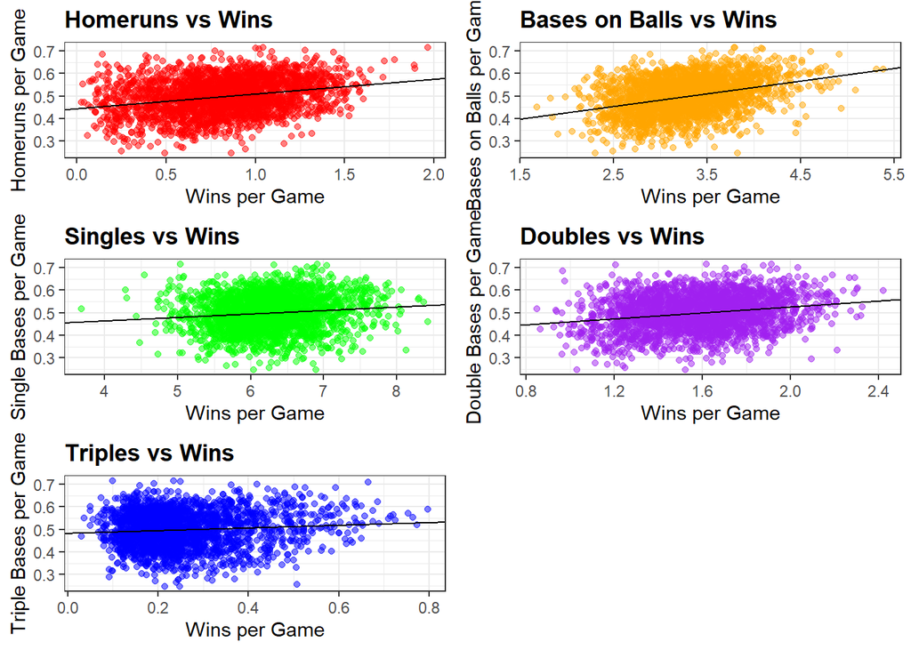

## Determine the Regression Line Value

Now that we have visualized this data, let’s compute the slope of the regression line for these relationships:

```r
# Compute the Slope of the regression line for BB
bb_slope <- Teams %>%
  filter(yearID %in% 1917:2021) %>%
  mutate(BB_per_game = BB/G, wins_per_game = W/G) %>%
  lm(wins_per_game ~ BB_per_game, data = .) %>%
  .$coef %>%
  .[2]
bb_slope
```

```
## BB_per_game
##       0.056
```

```r
# Compute the Slope of the regression line for singles
singles_slope <- Teams %>%
  filter(yearID %in% 1917:2021) %>%
  mutate(singles_per_game = (H-HR-X2B-X3B) / G, wins_per_game = W/G) %>%
  lm(wins_per_game ~ singles_per_game, data = .) %>%
  .$coef %>%
  .[2]
singles_slope
```

```
## singles_per_game
##           0.0153
```

```r
# Compute the Slope of the regression line for doubles
doubles_slope <- Teams %>%
  filter(yearID %in% 1917:2021) %>%
  mutate(doubles_per_game = X2B /G, wins_per_game = W/G) %>%
  lm(wins_per_game ~ doubles_per_game , data = .) %>%
  .$coef %>%
  .[2]
doubles_slope
```

```
## doubles_per_game
##           0.0657
```

```r
# Compute the Slope of the regression line for triples
triples_slope <- Teams %>%
  filter(yearID %in% 1917:2021) %>%
  mutate(triples_per_game = X3B /G, wins_per_game = W/G) %>%
  lm(wins_per_game ~ triples_per_game, data = .) %>%
  .$coef %>%
  .[2]
triples_slope
```

```
## triples_per_game
##           0.0594
```

```r
# Compute the Slope of the regression line for homeruns
bb_slope <- Teams %>%
  filter(yearID %in% 1917:2021) %>%
  mutate(HR_per_game = HR/G, wins_per_game = W/G) %>%
  lm(wins_per_game ~ HR_per_game, data = .) %>%
  .$coef %>%
  .[2]
bb_slope
```

```
## HR_per_game
##      0.0651
```